# LEPobuke: Vizuelizacija podataka u programskom okruženju R

Dušica Filipović Đurđević

1. mart 2023. godine

## Prvo se pobrinemo da nam radni direktorijum bude ono što mi želimo, najzgodnije – tamo gde su nam podaci

```r
setwd("C:/Sam/Dokumenti/Obuke/LEPggplot2_praksa_mart_2023")
```

- ko ne veruje, može da proveri:

```r
getwd()
```

```
## [1] "C:/Sam/Dokumenti/Obuke/LEPggplot2_praksa_mart_2023"
```

## Potom učitamo jedan mali i čist data frame

- ako nismo podesili radni direktorijum potrebno je prilagoditi putanji na svom hard disku:

```r
dat = read.table("cas2.podaci.txt",sep="\t", header=TRUE)
```

- proverimo dimenzije (broj redova i broj kolona) data frame-a

```r
dim(dat)
```

```
## [1] 100   6
```

- vidimo da postoji 100 redova i 6 kolona (to možemo da vidimo i u Environment)
- da vidimo naslove kolona

```r
colnames(dat)
```

```
## [1] "Ispitanik"    "Manipulacija" "Rukost"       "Nacitanost"   "IQ"
## [6] "RT"
```

## Napravimo mali uvid u prvih nekoliko redova

```r
head(dat)
```

```
##   Ispitanik    Manipulacija  Rukost Nacitanost IQ   RT
## 1        s1 kontrolna grupa levoruk        370 92 1648
## 2        s2 kontrolna grupa levoruk         80 94 1370
## 3        s3 kontrolna grupa levoruk        390 96 1663
## 4        s4 kontrolna grupa levoruk         90 96 1396
## 5        s5 kontrolna grupa levoruk        220 97 1521
## 6        s6 kontrolna grupa levoruk        110 97 1409
```

- vidimo da se u prvoj koloni nalaze šifre ispitanika, u drugoj podatak o pripadnosti nivou grupe u okviru varijable Manipulacija, u trećoj isto to za varijablu Rukost, u četvrtoj Nacitanost, u petoj IQ, u šestoj RT

## Možemo da proverimo tip podataka u kolonama

```r
class(dat$Ispitanik)
```

```
## [1] "character"
```

```r
class(dat$Manipulacija)
```

```
## [1] "character"
```

```r
class(dat$Rukost)
```

```
## [1] "character"
```

```r
class(dat$Nacitanost)
```

```
## [1] "integer"
```

```r
class(dat$IQ)
```

```
## [1] "integer"
```

```r
class(dat$RT)
```

```
## [1] "integer"
```

## Da vidimo koji nivoi varijabli postoje

```r
levels(dat$Ispitanik)
```

- promenimo klasu varijabli Ispitanik

```r
dat$Ispitanik = as.factor(dat$Ispitanik)
```

```r
levels(dat$Ispitanik)
```

```
##   [1] "s1"   "s10"  "s100" "s11"  "s12"  "s13"  "s14"  "s15"  "s16"  "s17"
##  [11] "s18"  "s19"  "s2"   "s20"  "s21"  "s22"  "s23"  "s24"  "s25"  "s26"
##  [21] "s27"  "s28"  "s29"  "s3"   "s30"  "s31"  "s32"  "s33"  "s34"  "s35"
##  [31] "s36"  "s37"  "s38"  "s39"  "s4"   "s40"  "s41"  "s42"  "s43"  "s44"
##  [41] "s45"  "s46"  "s47"  "s48"  "s49"  "s5"   "s50"  "s51"  "s52"  "s53"
##  [51] "s54"  "s55"  "s56"  "s57"  "s58"  "s59"  "s6"   "s60"  "s61"  "s62"
##  [61] "s63"  "s64"  "s65"  "s66"  "s67"  "s68"  "s69"  "s7"   "s70"  "s71"
##  [71] "s72"  "s73"  "s74"  "s75"  "s76"  "s77"  "s78"  "s79"  "s8"   "s80"
##  [81] "s81"  "s82"  "s83"  "s84"  "s85"  "s86"  "s87"  "s88"  "s89"  "s9"
##  [91] "s90"  "s91"  "s92"  "s93"  "s94"  "s95"  "s96"  "s97"  "s98"  "s99"
```

```r
dat$Manipulacija = as.factor(dat$Manipulacija)
levels(dat$Manipulacija)
```

```
## [1] "eksperimentalna grupa" "kontrolna grupa"
```

```r
dat$Rukost = as.factor(dat$Rukost)
levels(dat$Rukost)
```

```
## [1] "desnoruk" "levoruk"
```

## A možemo i sve odjednom:

```r
str(dat)
```

```
## 'data.frame':    100 obs. of  6 variables:
##  $ Ispitanik   : Factor w/ 100 levels "s1","s10","s100",..: 1 13 24 35 46 57 68 79 90 2 ...
##  $ Manipulacija: Factor w/ 2 levels "eksperimentalna grupa",..: 2 2 2 2 2 2 2 2 2 2 ...
##  $ Rukost      : Factor w/ 2 levels "desnoruk","levoruk": 2 2 2 2 2 2 2 2 2 2 ...
##  $ Nacitanost  : int  370 80 390 90 220 110 260 430 320 340 ...
##  $ IQ          : int  92 94 96 96 97 97 97 99 100 100 ...
##  $ RT          : int  1648 1370 1663 1396 1521 1409 1540 1706 1609 1627 ...
```

## A možemo i vizuelnim putem:

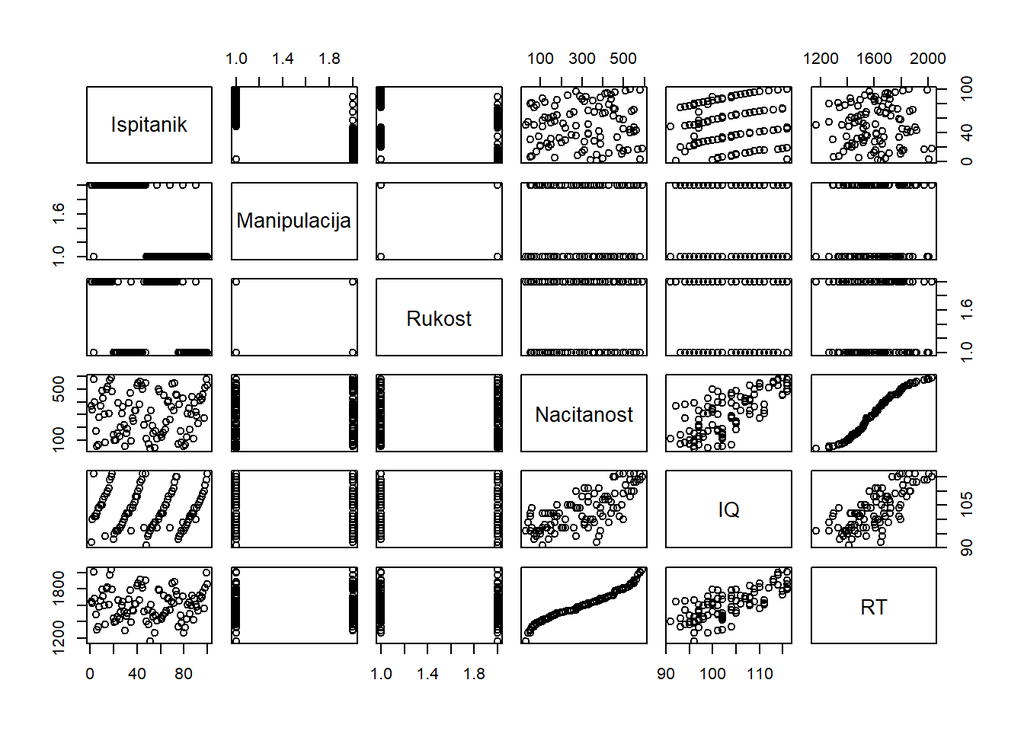

```r
plot(dat)
```

## Da vizualizujemo jednu varijablu

- napravimo prvo frekvencijsku tabelu pomoću table(), a onda tu tabelu prikažemo grafički

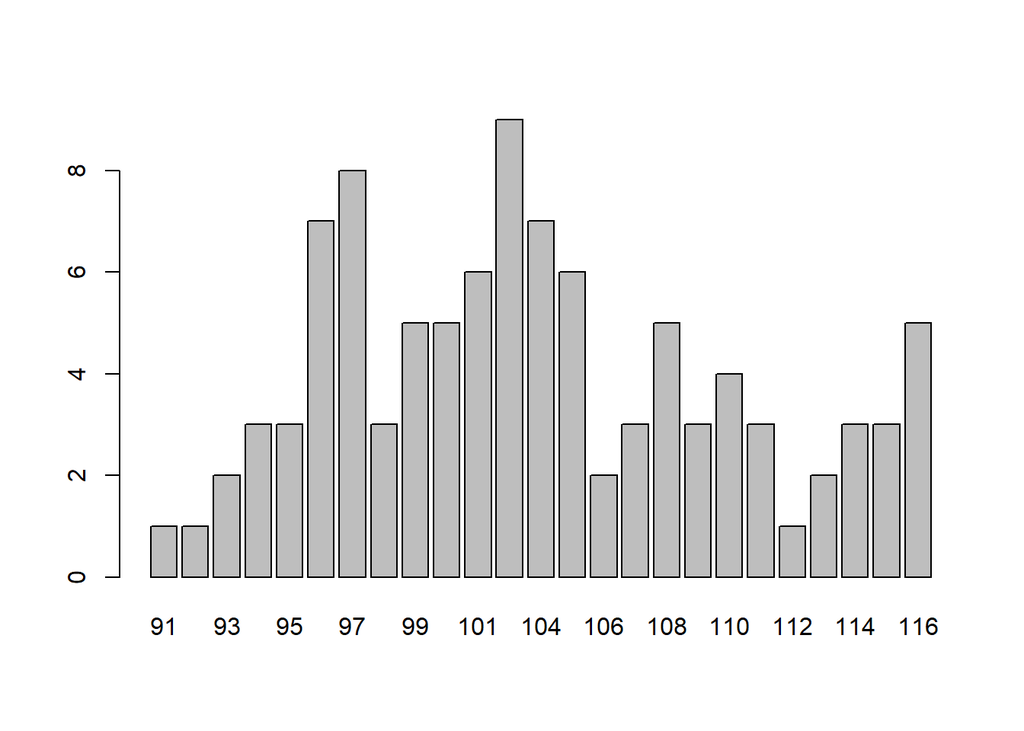

```r
barplot(table(dat$IQ))
```

## Dodamo nazive osa, naslov i promenimo boju

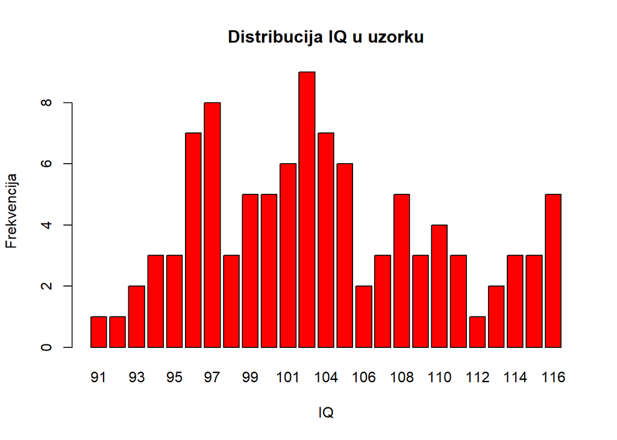

```r
barplot(table(dat$IQ),
        xlab="IQ", # naziv x ose
        ylab="Frekvencija", # naziv y ose
        main="Distribucija IQ u uzorku", # naslov na vrhu grafikona
        col="red") # boja stubića
```

## Dodamo deskriptivnu statistiku u naslov

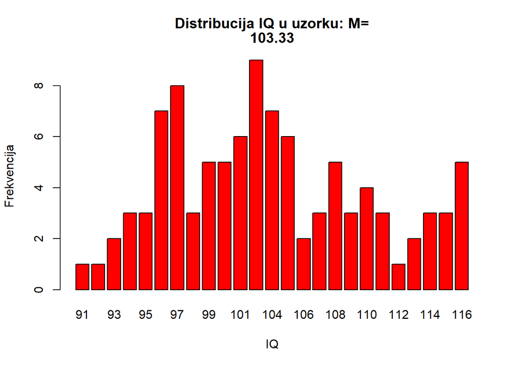

```r
barplot(table(dat$IQ),
        xlab="IQ",
        ylab="Frekvencija",
        main=c("Distribucija IQ u uzorku: M=", mean(dat$IQ)), #kombinujemo tekst i brojeve
        col="red")
```

## Grafikon koji smo napravili možemo sačuvati u fajl

```r
png("Grafikon1.png",
    width=400, height=400)

plot(density(dat$IQ))

dev.off()
```

## Grafički parametri

- Grafikon kao objekat kojim R operiše ima niz karakteristika
- Možemo sami upravljati izgledom grafikona tako što definišemo vrednosti grafičkih parametara
- To činimo komandom par(), a unutar zagrada navedemo ono što želimo da definišemo
- Da biste saznali koji sve parametri postoje i kako se menjaju kucajte ovu komandu ili pogledajte Help:

```r
par()
```

```
## $xlog
## [1] FALSE
##
## $ylog
## [1] FALSE
##
## $adj
## [1] 0.5
##
## $ann
## [1] TRUE
##
## $ask
## [1] FALSE
##
## $bg
## [1] "white"
##
## $bty
## [1] "o"
##
## $cex
## [1] 1
##
## $cex.axis
## [1] 1
##
## $cex.lab
## [1] 1
##
## $cex.main
## [1] 1.2
##
## $cex.sub
## [1] 1
##
## $cin
## [1] 0.15 0.20
##
## $col
```

[output cut: 160 more lines]

```
##
## $xpd
## [1] FALSE
##
## $yaxp
## [1] 0 1 5
##
## $yaxs
## [1] "r"
##
## $yaxt
## [1] "s"
##
## $ylbias
## [1] 0.2
```

```r
# ili ?par
```

## svoj omiljen seting možete sačuvati i u neku varijablu, pa ga kasnije poziveti

- npr:

```r
# moj_stil <- par(bg="transparent", col = "red", cex = 0.7)
# par(moj_stil)
```

## Prikažemo raspodelu IQ odvojeno za levoruke i desnoruke

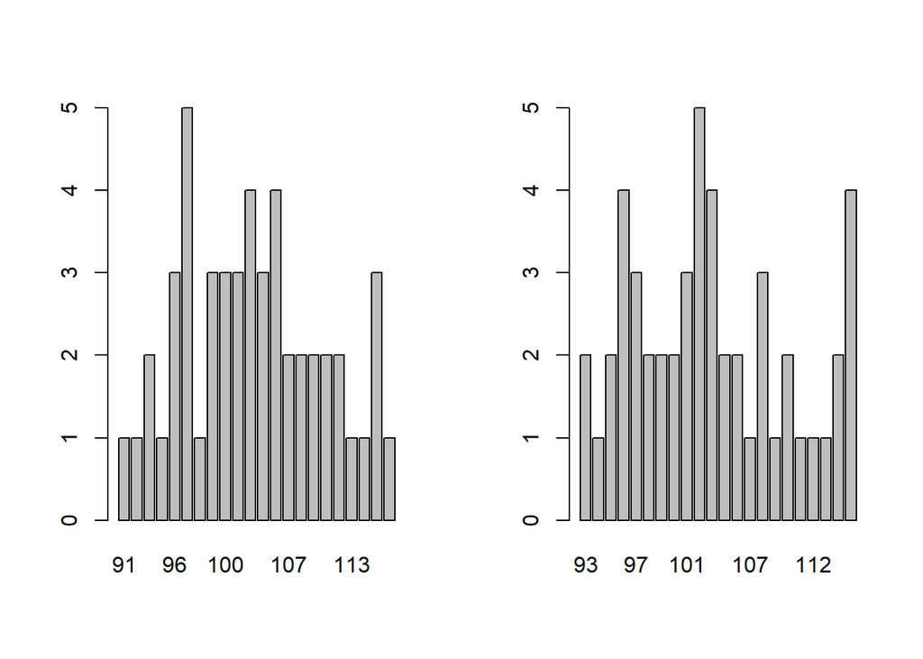

```r
par(mfrow=c(1, 2)) # podesimo grafički parametar na rešetku od 1 reda i 2 kolone

barplot(table(dat[dat$Rukost=="levoruk",]$IQ)) # tražimo IQ samo za levoruke

barplot(table(dat[dat$Rukost=="desnoruk",]$IQ)) # tražimo IQ samo za desnoruke
```

```r
par(mfrow=c(1,1)) # resetujemo grafički parametar na grid od 1 reda i 1 kolone
```

- isto to sa oznakama

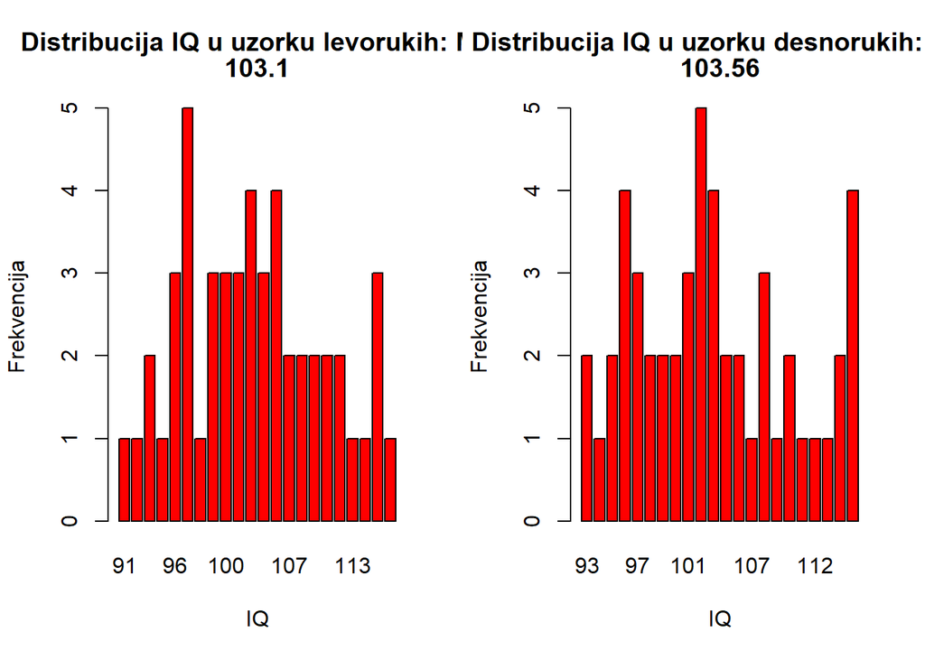

```r
par(mfrow=c(1, 2)) # podesimo grafički parametar na rešetku od 1 reda i 2 kolone

barplot(table(dat[dat$Rukost=="levoruk",]$IQ), # tražimo IQ samo za levoruke
        xlab="IQ",
        ylab="Frekvencija",
        main=c("Distribucija IQ u uzorku levorukih: M=", mean(dat[dat$Rukost=="levoruk",]$IQ)),
        col="red")

barplot(table(dat[dat$Rukost=="desnoruk",]$IQ), # tražimo IQ samo za desnoruke
        xlab="IQ",
        ylab="Frekvencija",
        main=c("Distribucija IQ u uzorku desnorukih: M=", mean(dat[dat$Rukost=="desnoruk",]$IQ)),
        col="red")
```

```r
par(mfrow=c(1,1)) # resetujemo grafički parametar na grid od 1 reda i 1 kolone
```

## Prikažemo raspodelu IQ odvojeno za levoruke i desnoruke, a unutar svakih odvojeno za kontrolnu i eksperimentalnu grupu

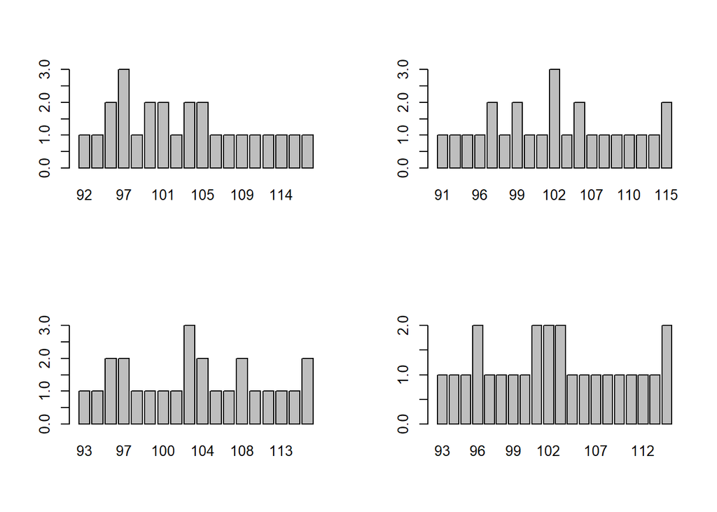

```r
par(mfrow=c(2, 2)) # naprvimo rešetku od dva reda i dve kolone (svaka ćelija za jedan grafikon)
# grafikoni se crtaju tako da se prvo pupuni prvi red s leva na desno, a potom drugi red
# ako želite da ih rasporedite tako da se prvo popuni prva kolona s vrha ka dnu,
# onda kucate par(mfcol=c(2, 2))

barplot(table(dat[dat$Rukost=="levoruk" & dat$Manipulacija=="kontrolna grupa",]$IQ))

barplot(table(dat[dat$Rukost=="levoruk" & dat$Manipulacija=="eksperimentalna grupa",]$IQ))

barplot(table(dat[dat$Rukost=="desnoruk" & dat$Manipulacija=="kontrolna grupa",]$IQ))

barplot(table(dat[dat$Rukost=="desnoruk" & dat$Manipulacija=="eksperimentalna grupa",]$IQ))
```

```r
par(mfrow=c(1,1))
```

## isto to sa oznakama

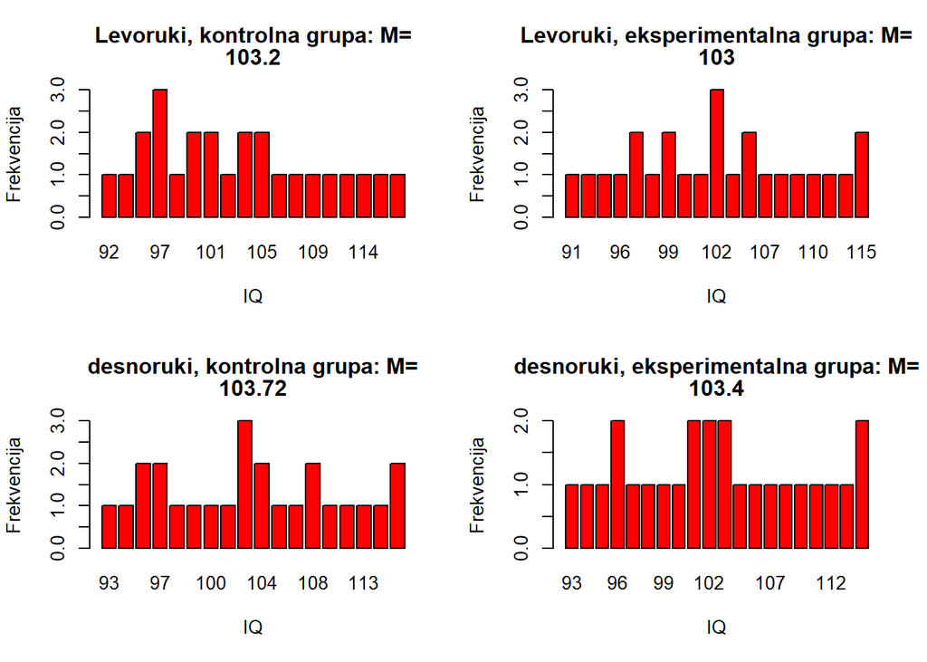

```r
par(mfrow=c(2, 2))
barplot(table(dat[dat$Rukost=="levoruk" & dat$Manipulacija=="kontrolna grupa",]$IQ),
        xlab="IQ",
        ylab="Frekvencija",
        main=c("Levoruki, kontrolna grupa: M=", mean(dat[dat$Rukost=="levoruk" & dat$Manipulacija=="kontrolna grupa",]$IQ)),
        col="red")

barplot(table(dat[dat$Rukost=="levoruk" & dat$Manipulacija=="eksperimentalna grupa",]$IQ),
        xlab="IQ",
        ylab="Frekvencija",
        main=c("Levoruki, eksperimentalna grupa: M=", mean(dat[dat$Rukost=="levoruk" & dat$Manipulacija=="eksperimentalna grupa",]$IQ)),
        col="red")

barplot(table(dat[dat$Rukost=="desnoruk" & dat$Manipulacija=="kontrolna grupa",]$IQ),
        xlab="IQ",
        ylab="Frekvencija",
        main=c("desnoruki, kontrolna grupa: M=", mean(dat[dat$Rukost=="desnoruk" & dat$Manipulacija=="kontrolna grupa",]$IQ)),
        col="red")

barplot(table(dat[dat$Rukost=="desnoruk" & dat$Manipulacija=="eksperimentalna grupa",]$IQ),
        xlab="IQ",
        ylab="Frekvencija",
        main=c("desnoruki, eksperimentalna grupa: M=", mean(dat[dat$Rukost=="desnoruk" & dat$Manipulacija=="eksperimentalna grupa",]$IQ)),
        col="red")
```

```r
par(mfrow=c(1,1))
```

## postoji i alternativni način, koji daje malo više slobode

```r
resetka <- matrix(c(1, 2, 1, 3, 4, 4), nrow = 3, ncol = 2, byrow=TRUE)
# napravimo matricu sa onoliko ćelija
# tj. redova i kolona koliko želimo da ima grafikona i
# rasporedimo brojeve u matricu na način na koji želimo da budu raspoređeni grafikoni,
# pri čemu redosled nizanja grafikona odgovara redosledu kojim ih zadajemo

resetka # da vidimo kako izgleda matrica za raspored
```

```
##      [,1] [,2]
## [1,]    1    2
## [2,]    1    3
## [3,]    4    4
```

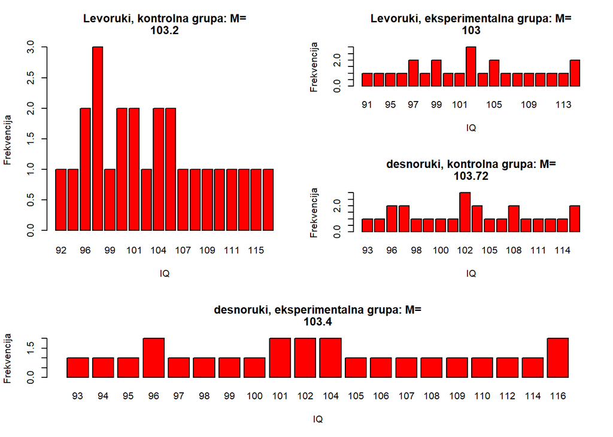

```r
layout(resetka) # tražimo da raspored prati našu matricu

barplot(table(dat[dat$Rukost=="levoruk" & dat$Manipulacija=="kontrolna grupa",]$IQ),
        xlab="IQ",
        ylab="Frekvencija",
        main=c("Levoruki, kontrolna grupa: M=", mean(dat[dat$Rukost=="levoruk" & dat$Manipulacija=="kontrolna grupa",]$IQ)),
        col="red")

barplot(table(dat[dat$Rukost=="levoruk" & dat$Manipulacija=="eksperimentalna grupa",]$IQ),
        xlab="IQ",
        ylab="Frekvencija",
        main=c("Levoruki, eksperimentalna grupa: M=", mean(dat[dat$Rukost=="levoruk" & dat$Manipulacija=="eksperimentalna grupa",]$IQ)),
        col="red")

barplot(table(dat[dat$Rukost=="desnoruk" & dat$Manipulacija=="kontrolna grupa",]$IQ),
        xlab="IQ",
        ylab="Frekvencija",
        main=c("desnoruki, kontrolna grupa: M=", mean(dat[dat$Rukost=="desnoruk" & dat$Manipulacija=="kontrolna grupa",]$IQ)),
        col="red")

barplot(table(dat[dat$Rukost=="desnoruk" & dat$Manipulacija=="eksperimentalna grupa",]$IQ),
        xlab="IQ",
        ylab="Frekvencija",
        main=c("desnoruki, eksperimentalna grupa: M=", mean(dat[dat$Rukost=="desnoruk" & dat$Manipulacija=="eksperimentalna grupa",]$IQ)),
        col="red")
```

```r
layout(1) # resetujemo rešetku za crtanje grafikona
```

## Napravimo histogram za raspodelu IQ

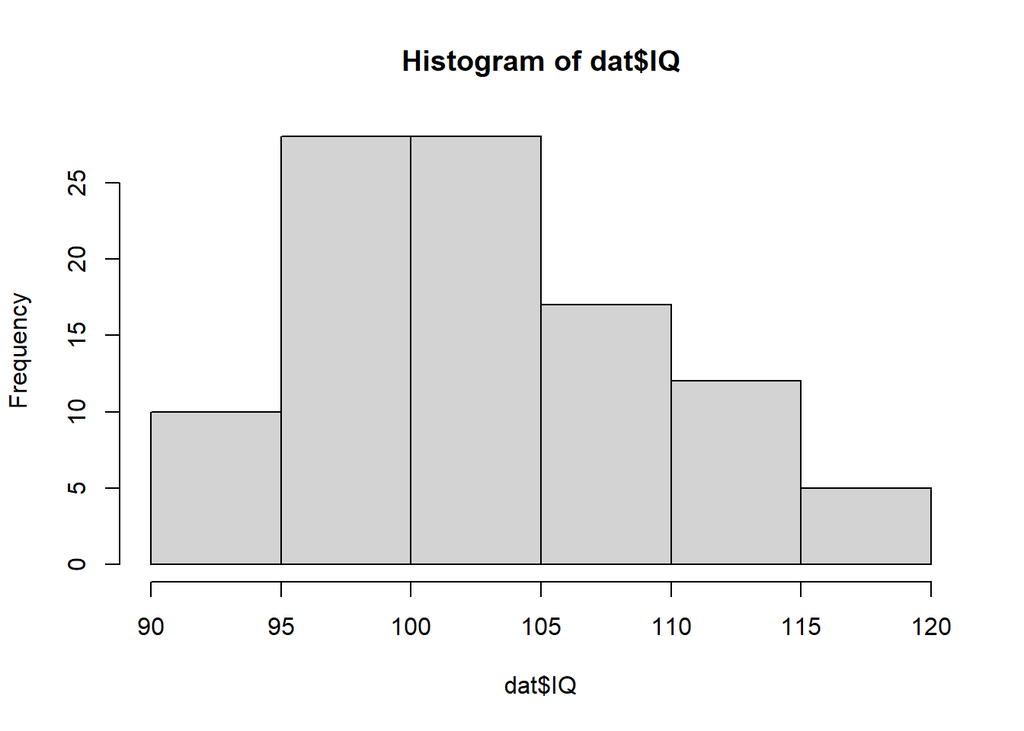

```r
hist(dat$IQ)
```

## isto to, ali sami odredimo broj kategorija

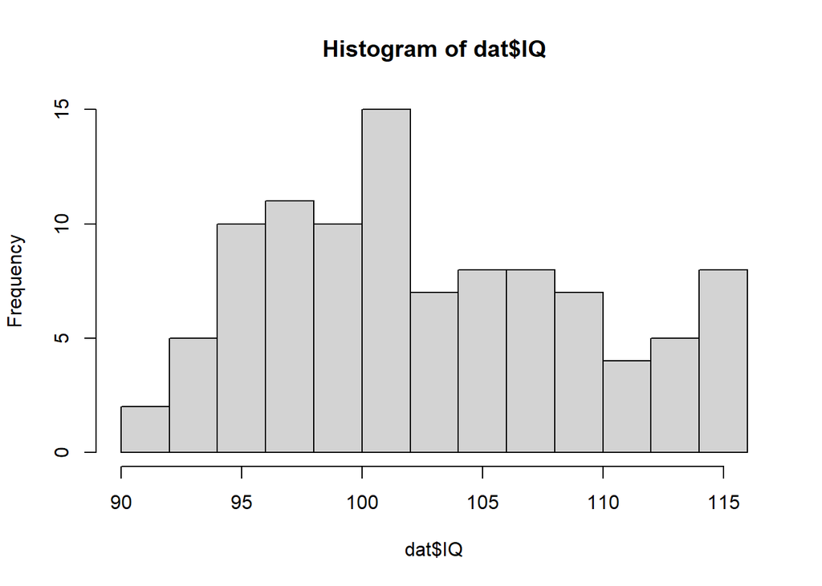

```r
hist(dat$IQ, breaks=10)
```

## Prikažemo gustinu raspodele varijable IQ

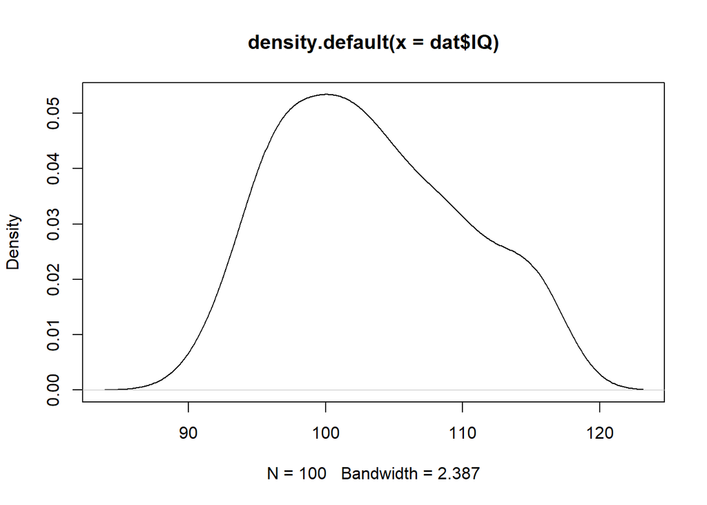

```r
plot(density(dat$IQ))
```

## kumulativno

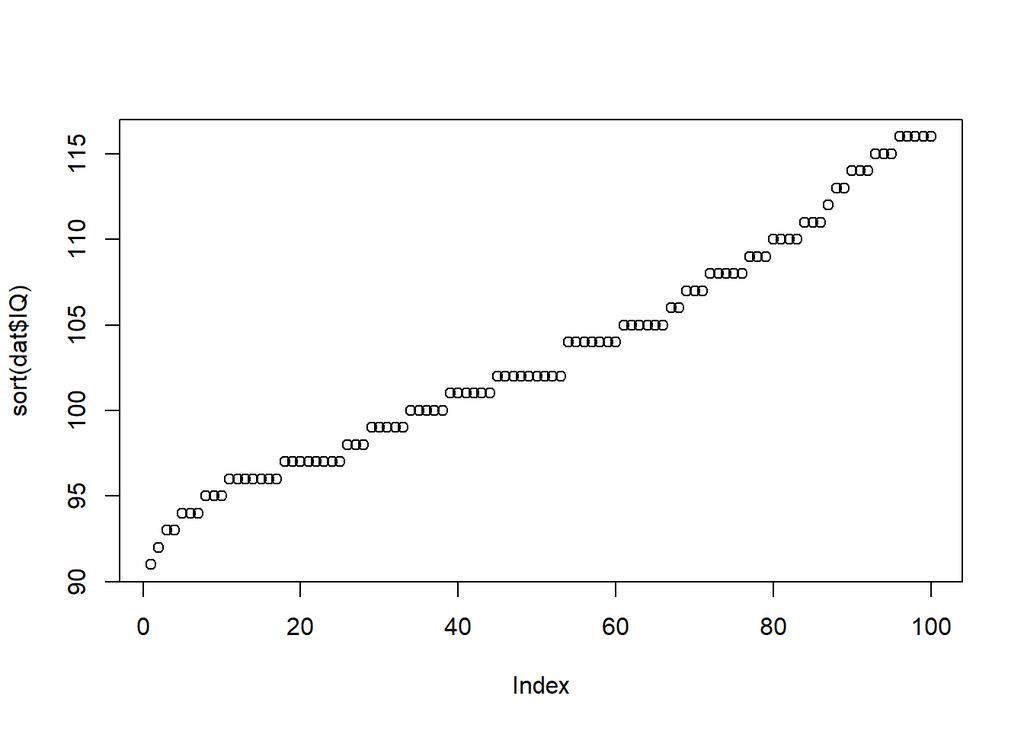

```r
plot(sort(dat$IQ))
```

## kvantili

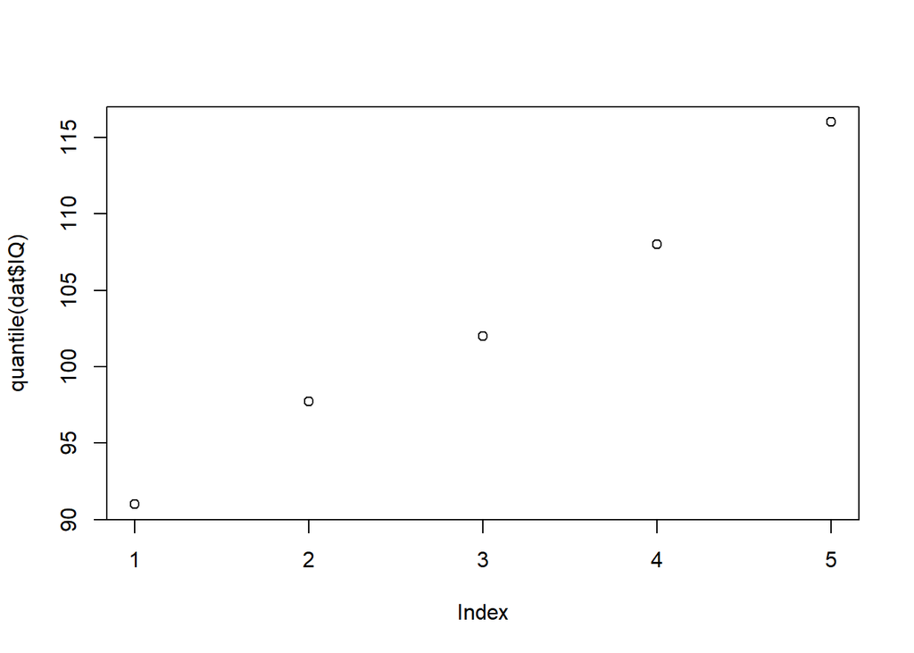

```r
plot(quantile(dat$IQ))
```

## decili

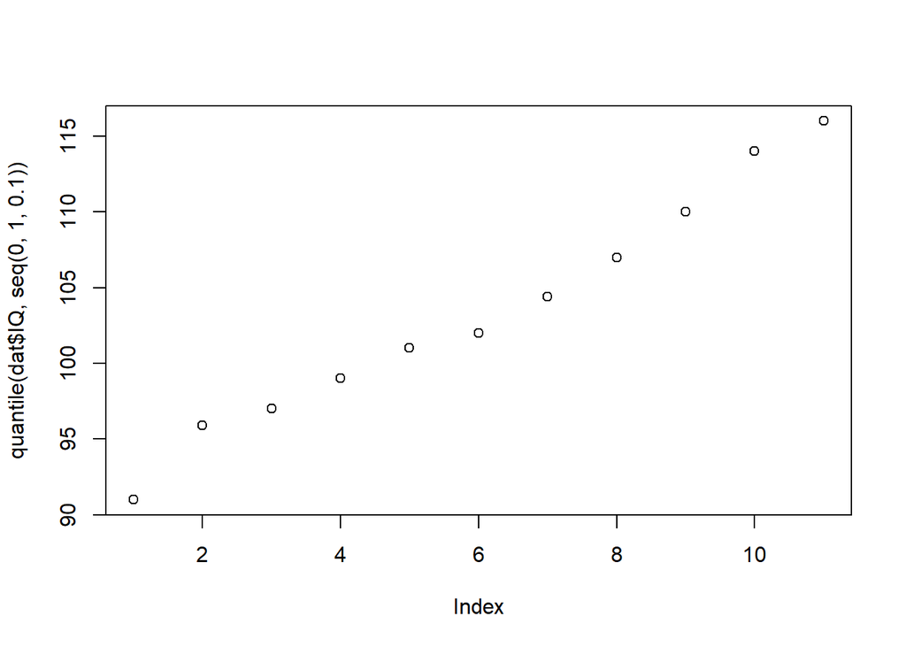

```r
plot(quantile(dat$IQ, seq(0,1, 0.1)))
```

## qqplot

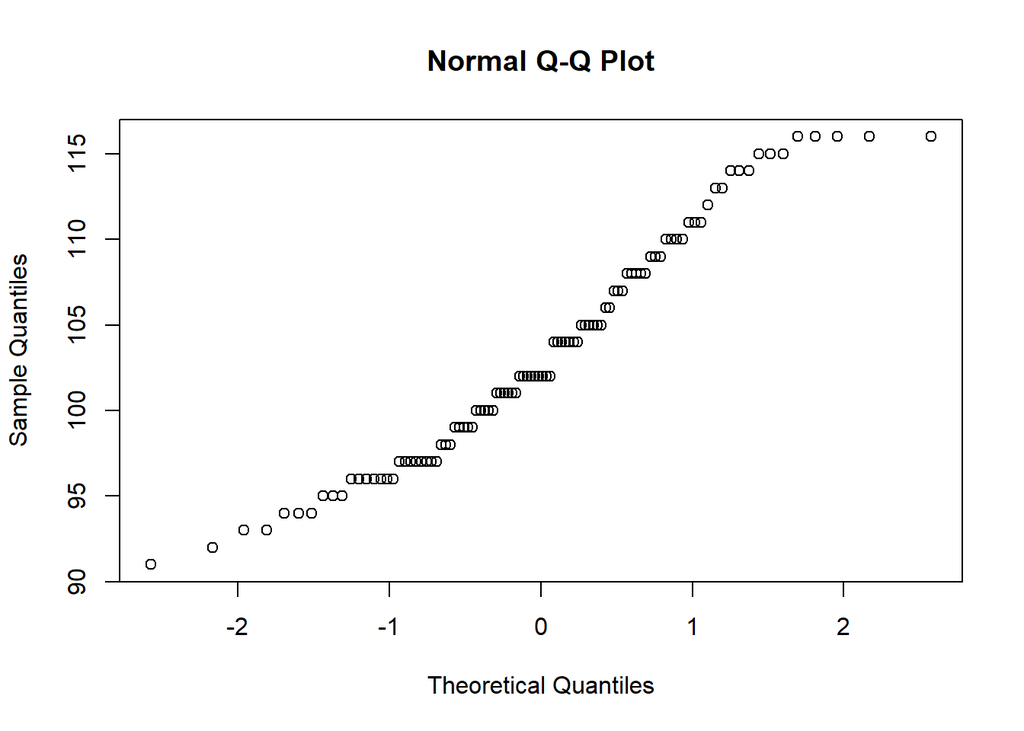

```r
qqnorm(dat$IQ)
```

## Scatterplot

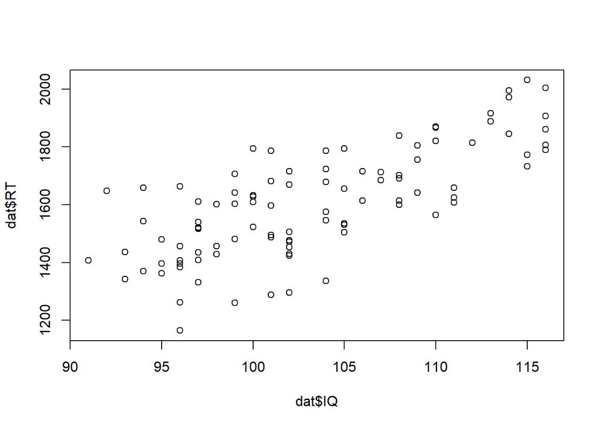

```r
plot(dat$IQ, dat$RT) # prvi argument: šta se mapira na x osu, drugi argument: šta se mapira na y osu
```

## Dodamo koeficijent korelacije u naslov

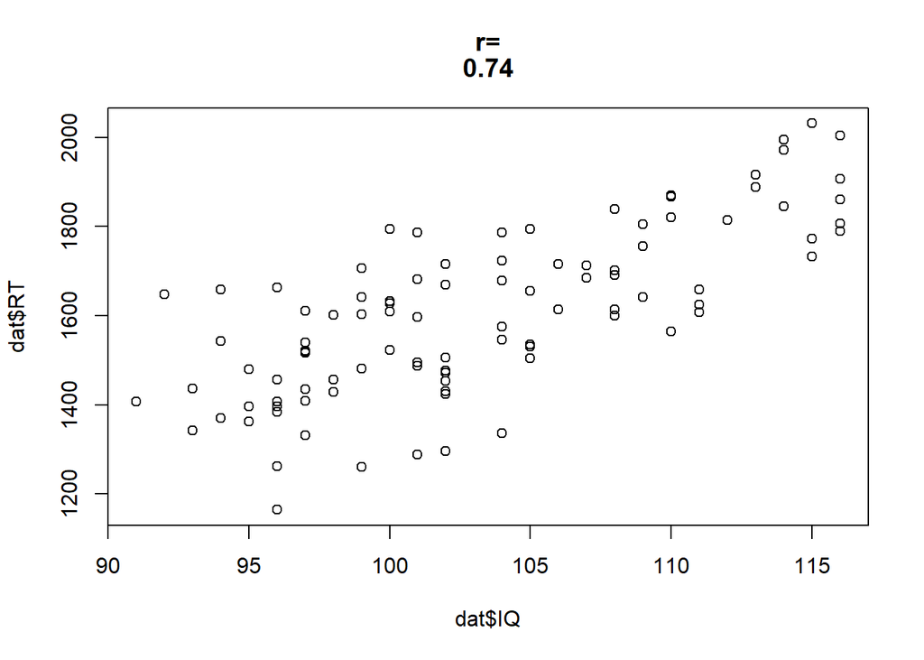

```r
x=cor(dat$IQ, dat$RT) # izračunamo koeficijent korelacije između dve varijable
x= round(x,2) # zaokružimo na dve decimale

plot(dat$IQ, dat$RT,
     main=c("r=", x)) # iskombinujemo tekst i broj (vrednost r) u naslovu
```

## Umesto tačaka prikažemo oznake ispitanika

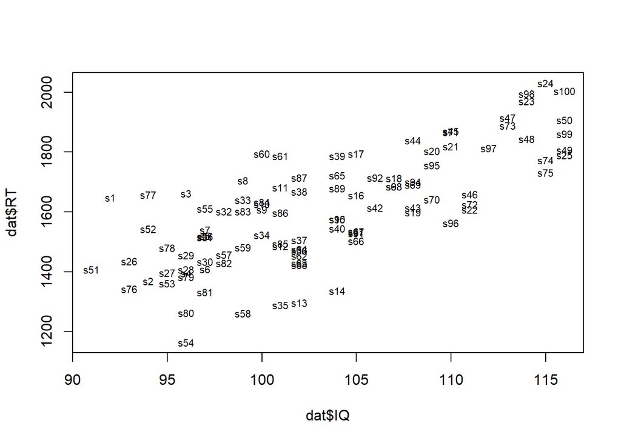

```r
plot(dat$IQ, dat$RT,
     type="n") # podesimo tip tačaka na "none" -- "ne dodaji ništa"

text(dat$IQ, dat$RT, # komanda za dodavanje reči umesto tačaka na grafikon; prvo damo koordinate
     as.character(dat$Ispitanik), # onda kažemo šta treba prikazati; konvertujemo u karaktere,
     #jer ova komanda zahteva vektor stringova (nizova karaktera)
     cex=0.7) # smanjimo font da bi bilo čitljivije
```

## dodamo regresionu pravu

```r
plot(dat$IQ, dat$RT,
     type="n") # podesimo tip tačaka na "none" -- "ne dodaji ništa"

text(dat$IQ, dat$RT, # komanda za dodavanje reči umesto tačaka na grafikon; prvo damo koordinate
     as.character(dat$Ispitanik), # onda kažemo šta treba prikazati; konvertujemo u karaktere,
     #jer ova komanda zahteva vektor stringova (nizova karaktera)
     cex=0.7) # smanjimo font da bi bilo čitljivije


lm_dat <- lm(RT ~ IQ, data=dat) # prvo napravimo linearni model
# dobijemo objekat koji sadrži regresione koeficijente
coef(lm_dat) # da vidimo koeficijente
```

```
## (Intercept)          IQ
##  -497.52579    20.35726
```

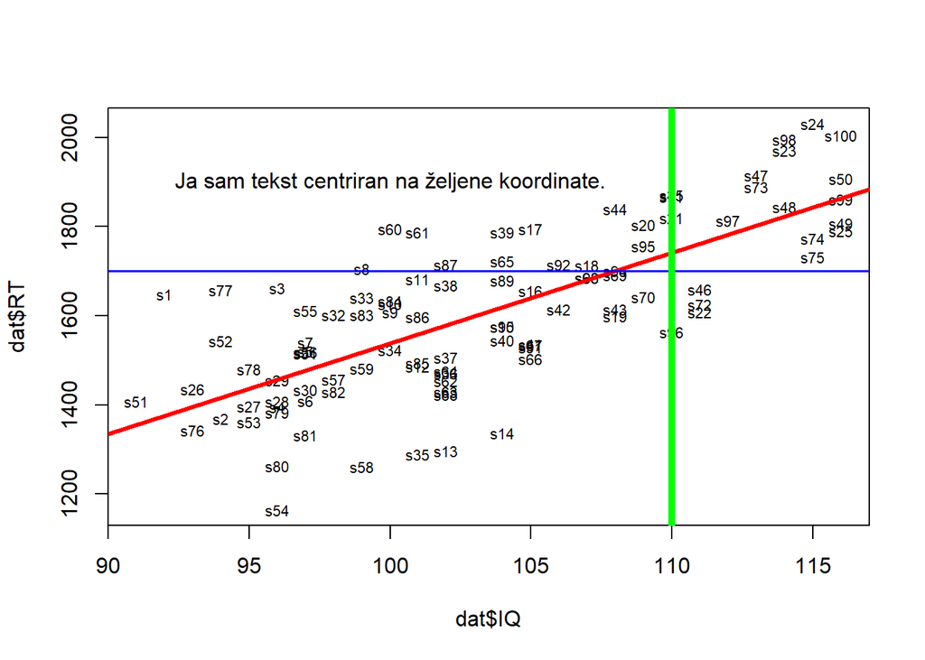

```r
abline(a=coef(lm_dat)[1], b=coef(lm_dat)[2])
# na osnovu tih koeficijenata nacrtamo regresionu liniju

abline(coef(lm_dat)) # ovo je isto kao komanda u gornjem redu, samo kraće

abline(coef(lm_dat), lwd = 3) # podebljamo liniju

abline(coef(lm_dat), lwd = 3, col="red") # linija da bude crvena

abline(h=1700, lwd=1.5, col="blue") # dodamo horizontalnu liniju

abline(v=110, lwd=5, col="green") # dodamo vertikalnu liniju

text(100, 1900, "Ja sam tekst centriran na željene koordinate.")
```

## Za brzi uvid u odnose među svim numeričkim varijablama

- sada nije impresivno, imamo samo tri numeričke varijable
- kada budemo radili analizu sa velikim brojem numeričkih prediktora, biće vrlo korisno kao prvi uvid u multikolinearnost

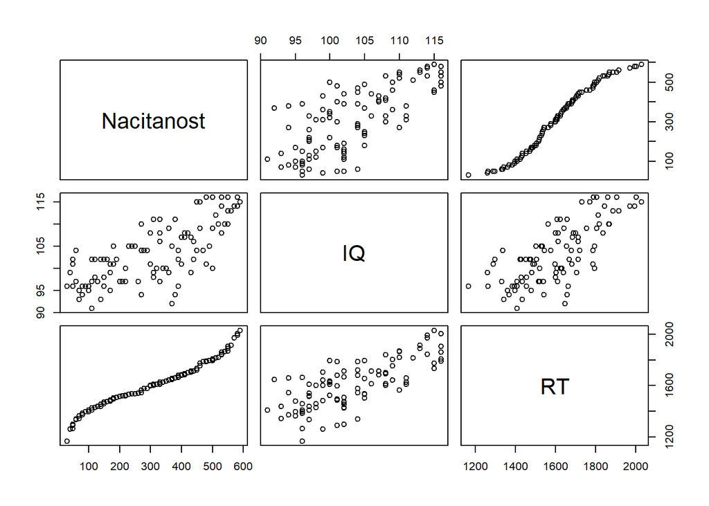

```r
pairs(dat[,c(4,5,6)]) # primeniti komandu na sve redove, na 4. i 5. kolonu data frame-a
```

## Isto to sa koeficijentima korelacije

- pozivamo funkviju koja je deo paketa languageR

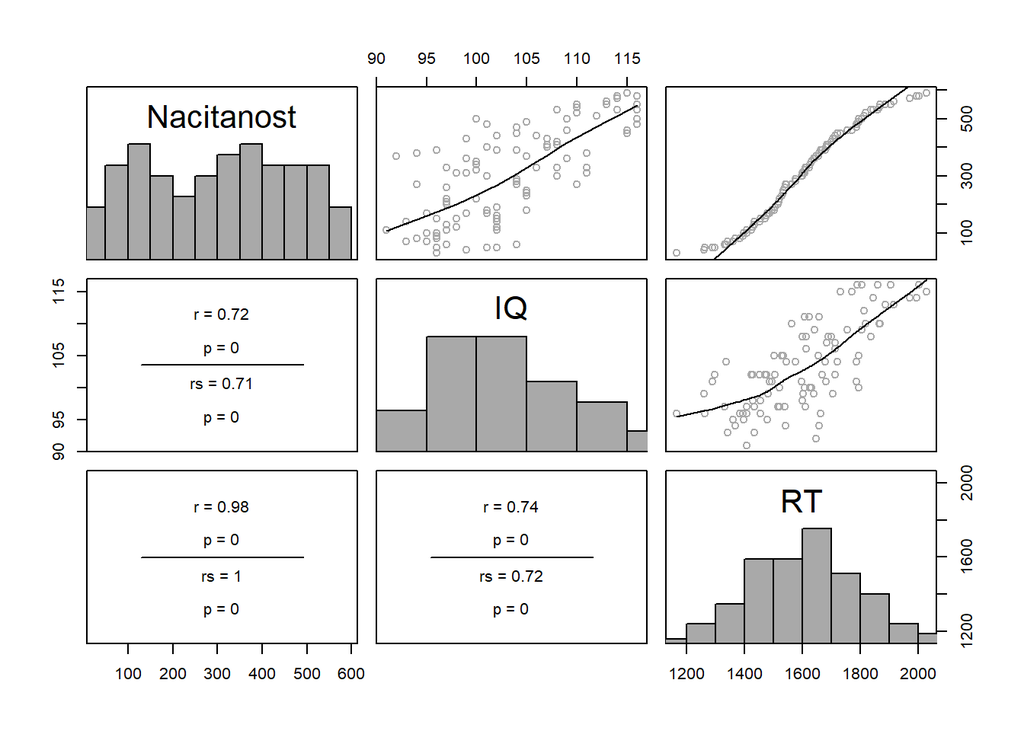

```r
library(languageR)
pairscor.fnc(dat[,c("Nacitanost", "IQ","RT" )], hist=TRUE, smooth=TRUE, cex.point=1, col.points="darkgrey")
```

## plotovanje funkcije

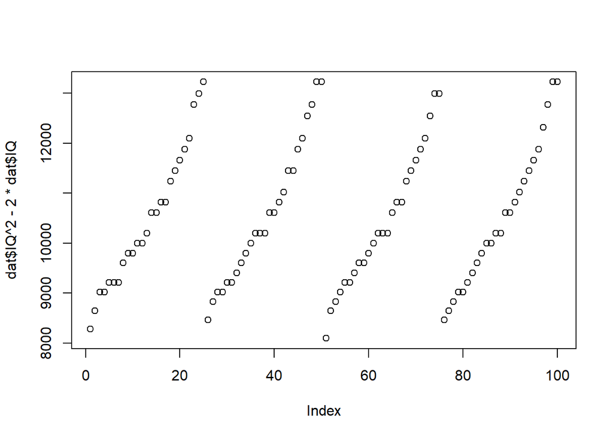

```r
plot(dat$IQ^2-2*dat$IQ)
```

## Box and whiskers plot

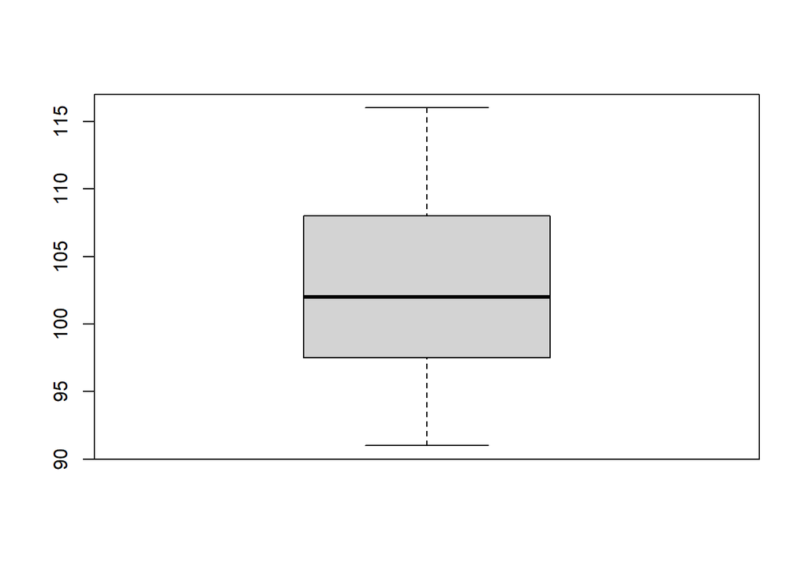

```r
boxplot(dat$IQ)
```

## Da prikažemo Box and whiskers plot po grupama

- nemojte ovo kucati sada (samo gledamo)

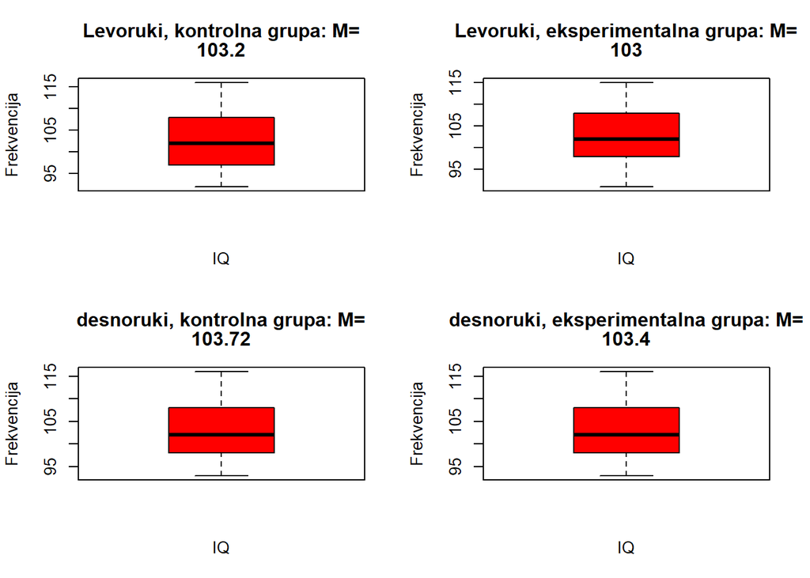

```r
par(mfrow=c(2, 2))
boxplot(dat[dat$Rukost=="levoruk" & dat$Manipulacija=="kontrolna grupa",]$IQ,
        xlab="IQ",
        ylab="Frekvencija",
        main=c("Levoruki, kontrolna grupa: M=", mean(dat[dat$Rukost=="levoruk" & dat$Manipulacija=="kontrolna grupa",]$IQ)),
        col="red")

boxplot(dat[dat$Rukost=="levoruk" & dat$Manipulacija=="eksperimentalna grupa",]$IQ,
        xlab="IQ",
        ylab="Frekvencija",
        main=c("Levoruki, eksperimentalna grupa: M=", mean(dat[dat$Rukost=="levoruk" & dat$Manipulacija=="eksperimentalna grupa",]$IQ)),
        col="red")

boxplot(dat[dat$Rukost=="desnoruk" & dat$Manipulacija=="kontrolna grupa",]$IQ,
        xlab="IQ",
        ylab="Frekvencija",
        main=c("desnoruki, kontrolna grupa: M=", mean(dat[dat$Rukost=="desnoruk" & dat$Manipulacija=="kontrolna grupa",]$IQ)),
        col="red")

boxplot(dat[dat$Rukost=="desnoruk" & dat$Manipulacija=="eksperimentalna grupa",]$IQ,
        xlab="IQ",
        ylab="Frekvencija",
        main=c("desnoruki, eksperimentalna grupa: M=", mean(dat[dat$Rukost=="desnoruk" & dat$Manipulacija=="eksperimentalna grupa",]$IQ)),
        col="red")
```

```r
par(mfrow=c(1,1))
```

## Isto to, sa mnogo manje kucanja - lattice

- Formula se čita kao: IQ u zavisnosti od nivoa fakotra Rukost i grupisano po nivoima faktora Manipulacija
- Kada budemo radili sa pravim podacima, vratićemo se na paket lattice (trellis grafiku), da vidimo njene pune moći

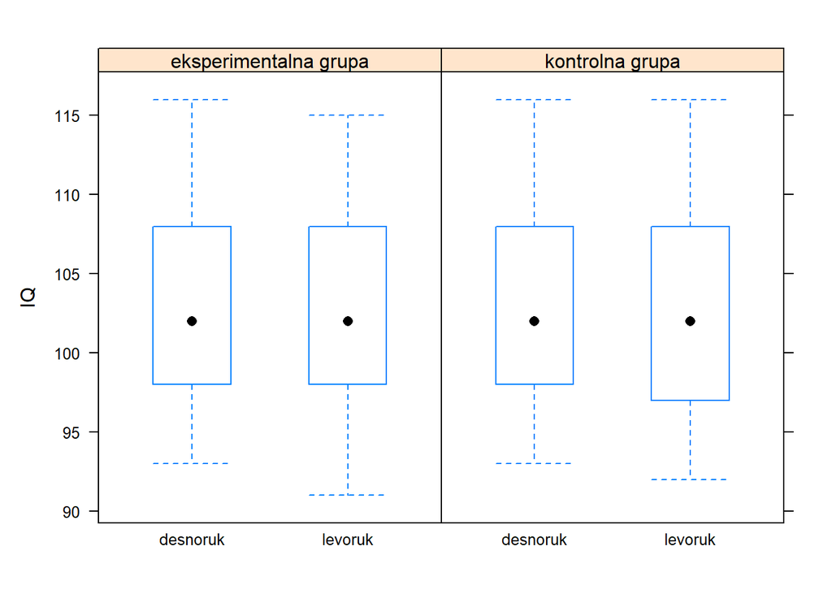

```r
library(lattice) # učitamo paket lattice
bwplot(IQ ~ Rukost | Manipulacija, # prvi argument je formula koja definiše šta prikazati
       data=dat) # drugi argument je data frame
```

## U istom paketu: skaterplot po kategorijama

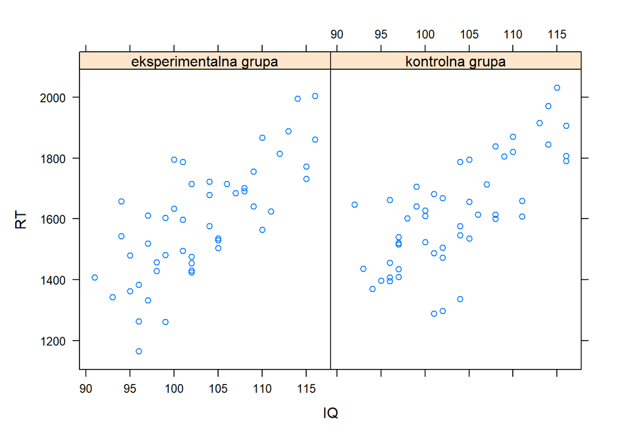

```r
xyplot(RT ~ IQ | Manipulacija,
       data=dat)
```

## ggplot2

- Paket napisan na osnovu knjige GRAMMAR OF GRAPHICS (Wilkinson, 1999)
- Trenutno najbolji i najzastupljeniji paket za grafičko prikazivanje
- Svaki grafikon ima barem tri osnovne komponente:
- 1. podatke
- 2. mapiranje varijabli na koordinate na osama, boju i veličinu: aes
- 3. način na koji treba prikazati svaku opseravciju (tačke, linije, stubići…): geom

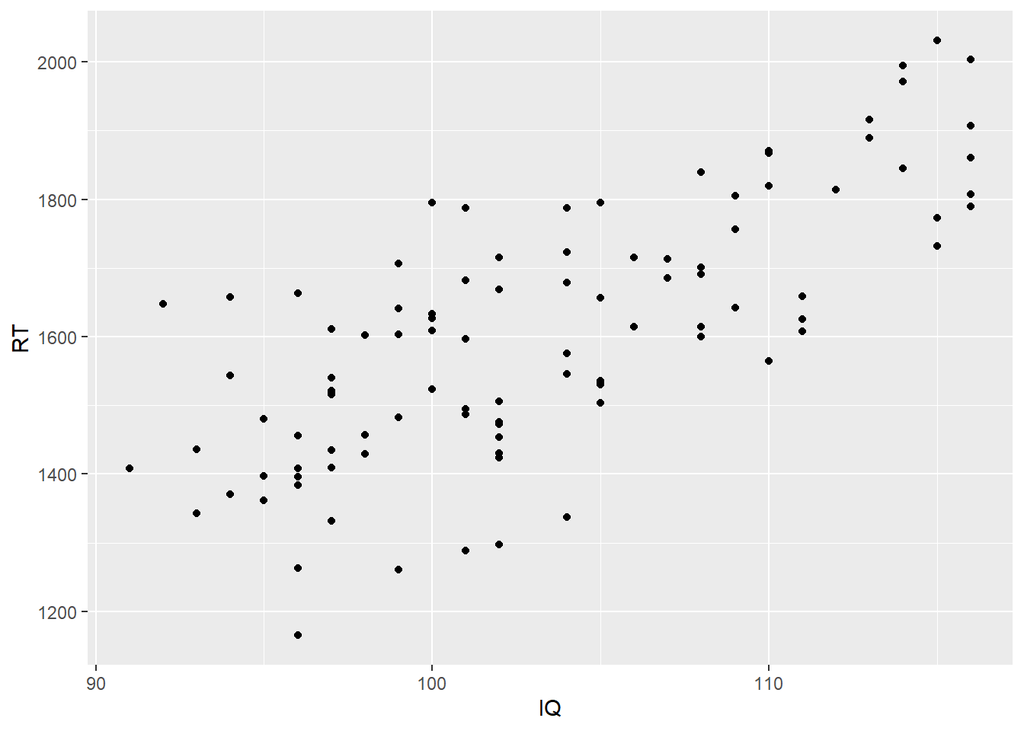

```r
library (ggplot2) # učitamo paket

ggplot(dat, # definišemo koji data frame treba koristiti
       aes(x = IQ, y = RT)) + # mapiramo varijable na ose
geom_point() # definišemo kako treba prikazati vrednosti: ovde kao tačke
```

## ggplot layers

- grafikon možemo da gradimo dodajući sloj po sloj
- koristeći + da dodajemo slojeve

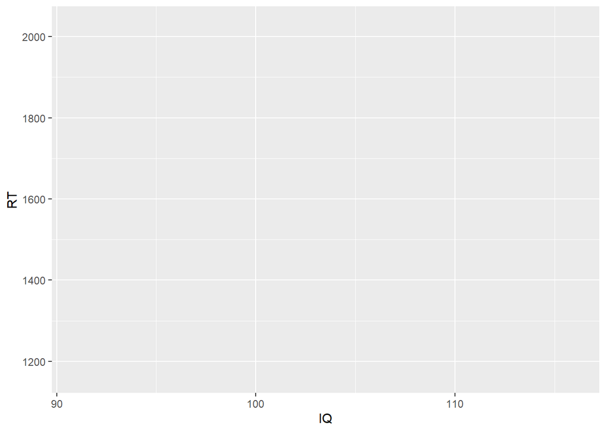

```r
g0 = ggplot(dat, aes(x=IQ, y=RT)) # osnovni grafikon sačuvamo u neku varijablu
g0 # vidimo da su tu samo ose
```

## Dodamo tačke

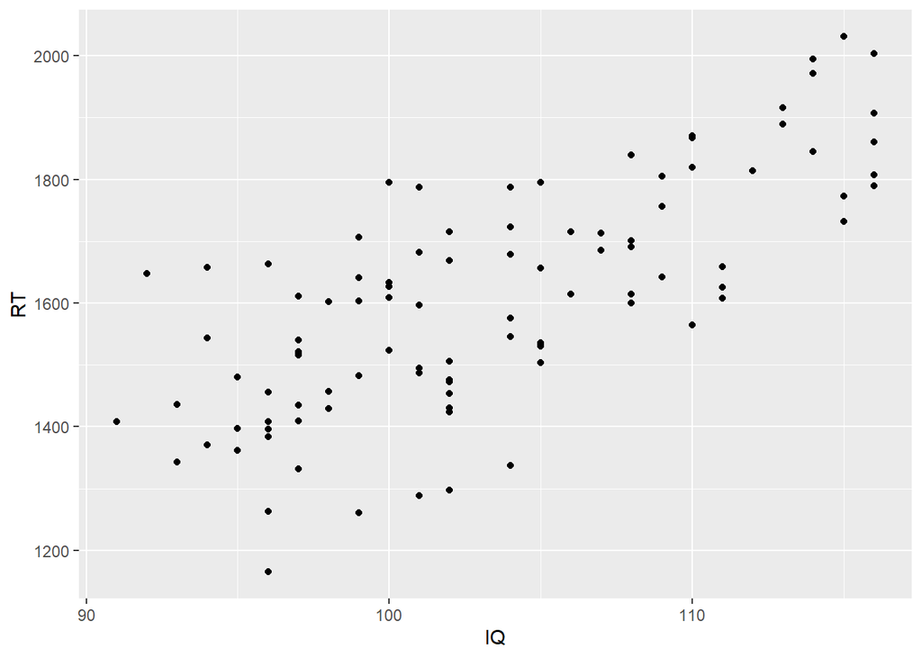

```r
g1 = g0 + # nove slojeve dodajemo pomoću znaka +
    geom_point() # da prikažemo tačke (skatterplot)
g1
```

## Dodamo naslov i nazive osa

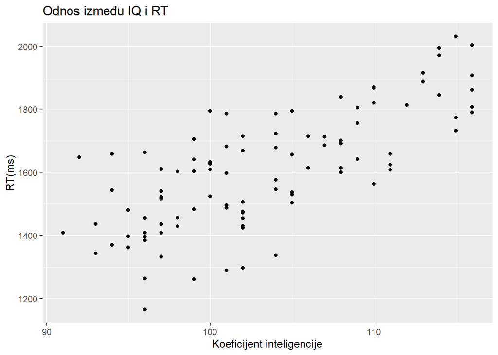

```r
g2 = g1 +
  ggtitle("Odnos između IQ i RT") + # damo naslov grafikonu
  xlab("Koeficijent inteligencije") + # damo naslov x osi
  ylab("RT(ms)") # damo naslov y osi

g2
```

## geom_point: boja tačaka

- Da promenimo boju svim tačkama

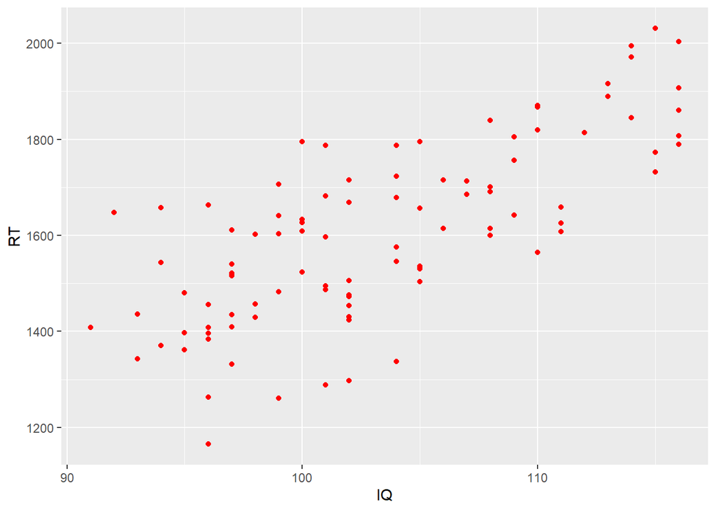

```r
g2 = g0 + geom_point(colour = "red")
g2
```